# Ökonometria

2. házi feladat

Granát Marcell

# 1. feladat

*Az alvással és a munkával töltött idő közötti átváltást, valamint az alvásidőt befolyásoló egyéb tényezőket vizsgáljuk a sleep75 adatbázis alapján (amely a „wooldridge” csomagban található). A függő változó az éjszakai alvással töltött összes idő percben (sleep), a magyarázó változók pedig a teljes heti munkaidő (totwrk), az iskolai évek száma és az életkor (educ, age), nem (male) és egy dummy változó, ami a kisgyerek jelenlétét mutatja a családban (yngkid).*

## a)

*Definiálja a foglalkoztatás három kategóriáját a heti ledolgozott órák alapján (hozzávetőlegesen: nem dolgozik [<4 óra], részmunkaidős [4-35 óra], teljes munkaidős [> 35 óra])! Vizsgálja meg az alvással töltött idő eloszlását boxplot-tal a foglalkoztatási kategóriák szerint! Adjon az ábrának címet, informatív tengelyfeliratokat stb.! Megjegyzés: itt használhatja a cut() függvényt.*

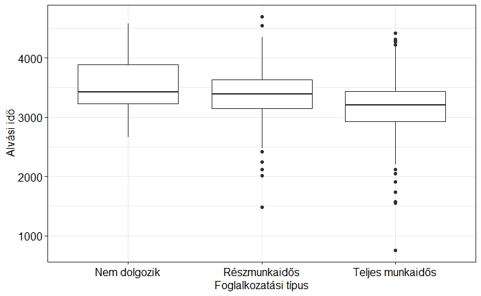

## b)

*Becsüljön meg három olyan regressziós modellt, amelyek függő változója a sleep, és az első modell egyetlen magyarázó változója totwrk, a második modell magyarázó változói totwrk és négyzete, a harmadik modell pedig a foglalkoztatási kategóriákat tartalmazza magyarázó változóként! (Természetesen minden modellben szerepeljen a konstans is.) Megjegyzés: a factor() függvény hasznos lehet ebben a részben.*

## c)

*Ábrázolja a sleep becsült függését a totwrk változótól egyetlen ábrában a három modell alapján kiszámítva!*

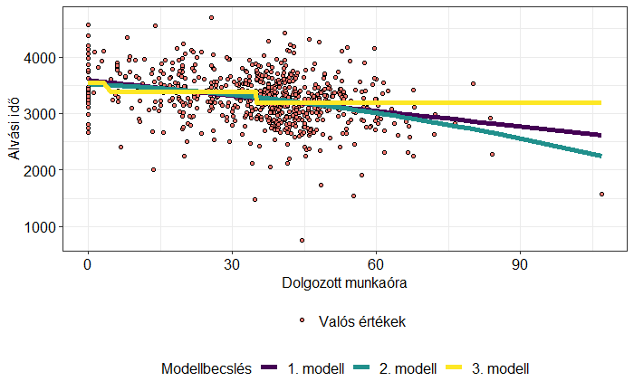

## d)

*Melyik modellt választaná a modellszelekciós kritériumok és az értelmezhetőség alapján?*

|  | R négyzet | Korrigált R négyzet | AIC | BIC |
| --- | --- | --- | --- | --- |
| 1. modell | 0,10 | 0,10 | 10540,19 | 10553,87 |
| 2. modell | 0,11 | 0,10 | 10538,90 | 10557,14 |
| 3. modell | 0,06 | 0,06 | 10574,40 | 10592,64 |

# 2. feladat

## a)

*Becsüljön meg egy többváltozós regressziós modellt úgy, hogy az alvással töltött idő a függő változó, és a munkával töltött idő, az életkor, az életkor négyzete, az iskolázottság, a nem és a kisgyermek jelenléte a magyarázó változó!*

## b)

*Értelmezze a nem és a kisgyermek jelenlétének paraméterbecslését!*

Amennyiben a kisgyermek, amely 3 évnél fiatalabb (yngkid = 1), úgy az alvásidő várhatóan ceteris paribus 0,0228 perccel kevesebb.

## c)

*Tesztelje 5%-os szinten, hogy a hibatag varianciája nem függ-e a magyarázó változóktól!*

- *Adja meg a tesztstatisztikát és a hozzá tartozó p-értéket!*
- *Értékelje a teszteredményt!*
- *Kell-e heteroszkedaszticitás-robusztus standard hibákat használni?*

[output not shown]

no

## d)

*Becsülje meg az alvással töltött időt egy 40 éves, teljes munkaidőben dolgozó, kisgyerekes és középfokú végzettséggel (azaz 12 éves oktatással) rendelkező férfi munkavállaló számára!*

```
       1
3302.445
```

## e)

*Adja meg a várható érték és a konkrét érték előrejelzésének standard hibáját!*

## f)

*Adjon 95%-os konfidencia-intervallumot a fenti két mennyiségre!*

## g)

*A (d) - (f) során melyik ponton feltételeztük a hibatag normális eloszlását a számítások során?*

## h)

*Vizsgálja meg egy megfelelő ábra segítségével, hogy a normalitás feltételezése (hozzávetőlegesen) igaz-e!*

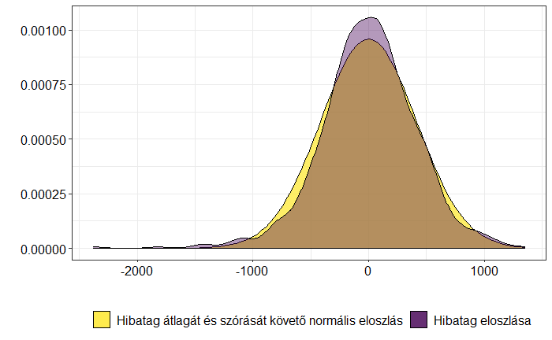

## i)

*A mintát ossza fel véletlenszerűen két azonos méretű részre! Becsülje meg a fenti modellt az egyik részmintán! Számítsa ki az átlagos négyzetes eltérést (MSE) a becslési mintán és a másik (teszt-) mintán is! Hasonlítsa össze az MSE értékeket és értelmezze az esetleges különbséget!*

```
 Becsles    Teszt
164773.1 182922.4
```

# 3. feladat

## a)

*Mennyivel különbözik a kisgyermekes és nem kisgyermekes szülők alvással töltött átlagos ideje a férfiak illetve a nők esetében?*

| Nem | Különbség |
| --- | --- |
| nő | 66,74 |
| férfi | -12,09 |

## b)

*Egészítse ki a yngkid és a male interakciójával a 3. feladat modelljét! Értelmezze a paraméterbecsléseket (és azok statisztikai szignifikanciáját), majd hasonlítsa össze azokat a 2. feladat megfelelő becslésével!*

# 4. feladat

*A titanic_small.xls fájl tartalmazza a Titanic utasainak egyéni jellemzőit: nem (sex=1 férfiak esetében, sex=2 nők esetében); az osztály, amelyen utaztak (pclass), életkor (age) és hogy túléltéke a katasztrófát (survived).*

## a)

*Számítsa ki a katasztrófát túlélő utazók százalékos arányát! Mennyire különbözik ez osztályonként?*

| Osztály | Túlélési arány |
| --- | --- |
| 1 | 61,92% |
| 2 | 42,96% |
| 3 | 25,53% |

## b)

*Becsüljön meg egy lineáris valószínűségi modellt (LPM), egy logit és egy probit modellt, függő változóként a túlélés valószínűségét, magyarázó változóként pedig az osztályt (mint kategorikus változót), a nemet és az életkort használva!*

## c)

*Számítsa ki az LPM, logit és probit modellek alapján a harmadosztályon és a másodosztályon utazók átlagos kontrollált túlélésvalószínűség-különbségét!*

[output not shown]

## d)

*Hasonlítsa össze ezt a három számot egymással és az a) rész eredményeivel!*

## e)

*A klasszifikációhoz használja a 0,5 értéket küszöbként. Számítsa ki a logit modell alapján a kétfajta klasszifikációs hibát és a helyesen besorolt megfigyelések arányát!*